# Test a Perceptual Phenomenon (1)

### Analyzing the Stroop Effect

Perform the analysis in the space below. Remember to follow [the instructions](https://docs.google.com/document/d/1-OkpZLjG_kX9J6LIQ5IltsqMzVWjh36QpnP2RYpVdPU/pub?embedded=True) and review the [project rubric](https://review.udacity.com/#!/rubrics/71/view) before submitting. Once you've completed the analysis and write-up, download this file as a PDF or HTML file, upload that PDF/HTML into the workspace here (click on the orange Jupyter icon in the upper left then Upload), then use the Submit Project button at the bottom of this page. This will create a zip file containing both this .ipynb doc and the PDF/HTML doc that will be submitted for your project.

(1) What is the independent variable? What is the dependent variable?

The independent variables: Two conditions (congruent word condition and incongruent word condition).

The dependent variable: ink colors reading time.

(2) What is an appropriate set of hypotheses for this task? Specify your null and alternative hypotheses, and clearly define any notation used. Justify your choices.

$$H_0:\mu_c-\mu_i=0$$

Null hypothesis: there is no difference in the mean time to read ink colors between congruent and incongruent.

$$H_1:\mu_c-\mu_i\neq0$$

Alternative hypothesis: there is a difference in the mean time to read ink colors between congruent and incongruent.

we will perofrm t-test analysis (two-tailed). as the standard deviation is unknown and the sample size is small which is 24 as per the statistical anaylsis below

(3) Report some descriptive statistics regarding this dataset. Include at least one measure of central tendency and at least one measure of variability. The name of the data file is 'stroopdata.csv'.

```python
# Perform the analysis here
#import libraries
import pandas as pd
import numpy as np


import matplotlib.pyplot as plt
%matplotlib inline
```

```python
#read file and display the first five rows
df = pd.read_csv('stroopdata.csv')
df.head()
```

|  | Congruent | Incongruent |
| --- | --- | --- |
| 0 | 12.079 | 19.278 |
| 1 | 16.791 | 18.741 |
| 2 | 9.564 | 21.214 |
| 3 | 8.630 | 15.687 |
| 4 | 14.669 | 22.803 |

```python
#sample size by retrieving rows number
df.shape
```

```
(24, 2)
```

```python
#create a new column for difference data
df['difference'] = df.Incongruent - df.Congruent
df.describe()
```

|  | Congruent | Incongruent | difference |
| --- | --- | --- | --- |
| count | 24.000000 | 24.000000 | 24.000000 |
| mean | 14.051125 | 22.015917 | 7.964792 |
| std | 3.559358 | 4.797057 | 4.864827 |
| min | 8.630000 | 15.687000 | 1.950000 |
| 25% | 11.895250 | 18.716750 | 3.645500 |
| 50% | 14.356500 | 21.017500 | 7.666500 |
| 75% | 16.200750 | 24.051500 | 10.258500 |
| max | 22.328000 | 35.255000 | 21.919000 |

from the table above we can find the follwing:

```python
#calculate mean and standard deviation for the difference
diffmean = 7.96
diffstd = 4.86
```

From the dataset above we find that we have two headers which are Congruent and Incongruent. Difference is calculated as well.

(4) Provide one or two visualizations that show the distribution of the sample data. Write one or two sentences noting what you observe about the plot or plots.

```
The histogram below shows the time to read the ink colors for Incongruent
```

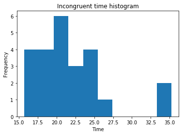

```python
# Build the visualizations here

print('The histogram below shows the time to read the ink colors for Incongruent')
plt.hist(df.Incongruent)

plt.title('Incongruent time histogram')
plt.xlabel('Time')
plt.ylabel('Frequency')

plt.show()
```

```
The histogram below shows the time to read the ink colors for Congruent
```

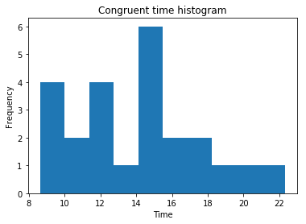

```python
print('The histogram below shows the time to read the ink colors for Congruent')


plt.hist(df.Congruent)

plt.title('Congruent time histogram')
plt.xlabel('Time')
plt.ylabel('Frequency')

plt.show()
```

From the above histograms we can conclude that the data is normally distrbuted for small sample size and also we have difference in reading times between the incongruent and congruent conditions.

(5) Now, perform the statistical test and report your results. What is your confidence level or Type I error associated with your test? What is your conclusion regarding the hypotheses you set up? Did the results match up with your expectations? **Hint:** Think about what is being measured on each individual, and what statistic best captures how an individual reacts in each environment.

t-test setps:

1. Null hypothesis is selected
2. Alternative hypothesis is selected
3. Set: α = .05 with 95% confidence level
4. Degrees of freedom (df) = n - 1 = 24 - 1 = 23
5. From t-table: t-critical Value (two-tailed) = 2.069 and -2.069
6. Calculate t-value

```python
# Perform the statistical test here
#t-value
tvalue = diffmean / (diffstd / (24**.5))

print(tvalue)
```

```
8.023842943437899
```

As a result, calculated t-value=8.02 and t-critical Value (two-tailed) = 2.069 and -2.069, t-value is greater than t-critial value so reject Null hypothesis which confirms there is a difference in ink colors reading time for two conditions (congruent word and incongruent word).

References:

https://newonlinecourses.science.psu.edu/stat502/node/139/ https://www.medcalc.org/manual/t-distribution.php https://www.investopedia.com/terms/t/t-test.asp